## "On my honor, as a student, I have neither given nor received unauthorized aid on this academic work."

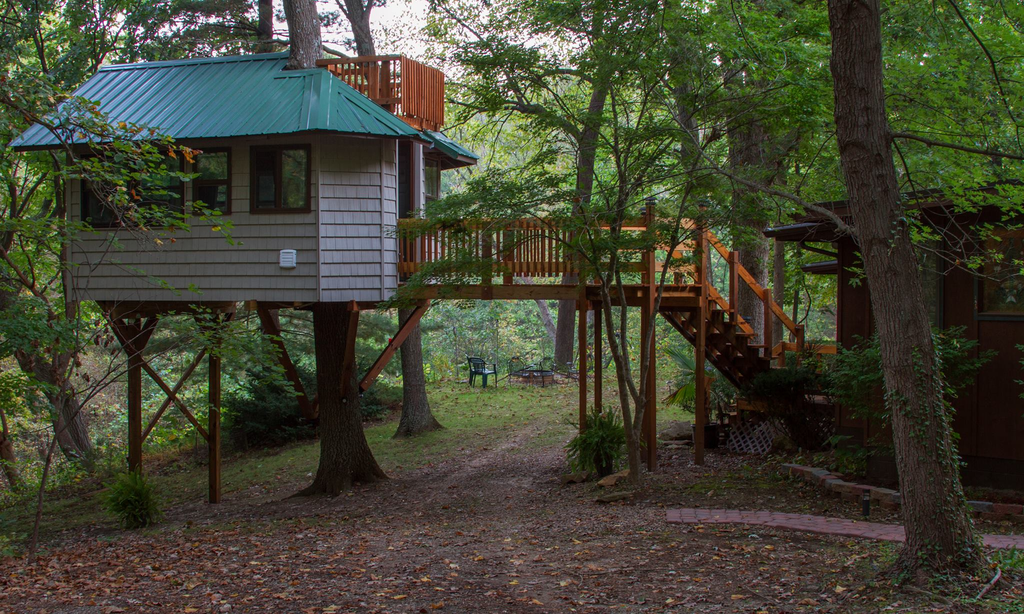

```python
from IPython.display import Image
Image('23415603_1729708343729574_4288131267468805454_o.jpg')
```

# Hidden Valley Wilderness Retreat Market Analysis

## The purpose of this project is to analyze the market for a Wilderness retreat. We want to define WHO is interested/interacts with the retreat, WHAT guests that have stayed like and do not like, and WHERE they are located. Using this information, the owners will be able to analyze what people do and don't like about the retreat, who their target market is and where they are located. Given this information, they can find ways to penetrate deeper into their current market or find ways to reach out to markets that they currently do not appeal to.

## This data will also be used to develop a marketing strategy for a new stand alone tree house that will be opened in summer 2018.

# 1 Data Collection: First we need to collect data, for this project we will be collecting data off the facebook fan page

### A script is ran to collect all the posts off of the fan page and stored into a csv. The Code is displayed below.

# https://github.com/minimaxir/facebook-page-post-scraper import urllib2 import json import datetime import csv import time #[1] First, install facebook-sdk (if this is not installed yet) #pip install facebook-sdk #[2] log into your Facebook account #[3] go to https://developers.facebook.com/tools/explorer #[4] copy your access token access_token = 'EAACEdEose0cBAHCnaa1ZBjh5Q05TX8wzeqJ8FzajoCOGXKS1Otnwa470T3JyLmcyW6bSrxYePoL2OTPgXdKwWwB0RDTB1U1jjxUVrKNrI7Pf41LsKhGyRsI1x0VPTv24tVx85E16E7MTjM2yZAXruPoStZBkghZCUIdNkbXJ4BhycD7x1auAVBbk1N7kqOgZD' page_id = "hiddenvalleywilderness" # a small fan page for demonstration purpose def request_until_succeed(url): req = urllib2.Request(url) success = False while success is False: try: response = urllib2.urlopen(req) if response.getcode() == 200: success = True except Exception, e: print e time.sleep(5) print "Error for URL %s: %s" % (url, datetime.datetime.now()) print "Retrying." return response.read() # Needed to write tricky unicode correctly to csv def unicode_normalize(text): return text.translate({ 0x2018:0x27, 0x2019:0x27, 0x201C:0x22, 0x201D:0x22, 0xa0:0x20 }).encode('utf-8') def getFacebookPageFeedData(page_id, access_token, num_statuses): # Construct the URL string; see http://stackoverflow.com/a/37239851 for # Reactions parameters base = "https://graph.facebook.com/v2.9" node = "/%s/posts" % page_id fields = "/?fields=message,link,created_time,type,name,id," + \ "comments.limit(0).summary(true),shares,reactions" + \ ".limit(0).summary(true)" parameters = "&limit=%s&access_token=%s" % (num_statuses, access_token) # you can change the duration of data collection #parameters = "/?fields=message,link,created_time,type,name,id,likes.limit(1).summary(true),comments.limit(1).summary(true),shares&since=2018-01-01&limit=%s&access_token=%s" % (num_statuses, access_token) # changed url = base + node + fields + parameters # retrieve data data = json.loads(request_until_succeed(url)) return data def getReactionsForStatus(status_id, access_token): # See http://stackoverflow.com/a/37239851 for Reactions parameters # Reactions are only accessable at a single-post endpoint base = "https://graph.facebook.com/v2.9" node = "/%s" % status_id reactions = "/?fields=" \ "reactions.type(LIKE).limit(0).summary(total_count).as(like)" \ ",reactions.type(LOVE).limit(0).summary(total_count).as(love)" \ ",reactions.type(WOW).limit(0).summary(total_count).as(wow)" \ ",reactions.type(HAHA).limit(0).summary(total_count).as(haha)" \ ",reactions.type(SAD).limit(0).summary(total_count).as(sad)" \ ",reactions.type(ANGRY).limit(0).summary(total_count).as(angry)" parameters = "&access_token=%s" % access_token url = base + node + reactions + parameters # retrieve data data = json.loads(request_until_succeed(url)) return data def processFacebookPageFeedStatus(status, access_token): # The status is now a Python dictionary, so for top-level items, # we can simply call the key. # Additionally, some items may not always exist, # so must check for existence first status_id = status['id'] status_message = '' if 'message' not in status.keys() else \ unicode_normalize(status['message']) link_name = '' if 'name' not in status.keys() else \ unicode_normalize(status['name']) status_type = status['type'] status_link = '' if 'link' not in status.keys() else \ unicode_normalize(status['link']) # Time needs special care since a) it's in UTC and # b) it's not easy to use in statistical programs. status_published = datetime.datetime.strptime( status['created_time'],'%Y-%m-%dT%H:%M:%S+0000') status_published = status_published + \ datetime.timedelta(hours=-5) # EST status_published = status_published.strftime( '%Y-%m-%d %H:%M:%S') # best time format for spreadsheet programs # Nested items require chaining dictionary keys. num_reactions = 0 if 'reactions' not in status else \ status['reactions']['summary']['total_count'] num_comments = 0 if 'comments' not in status else \ status['comments']['summary']['total_count'] num_shares = 0 if 'shares' not in status else status['shares']['count'] # Counts of each reaction separately; good for sentiment # Only check for reactions if past date of implementation: # http://newsroom.fb.com/news/2016/02/reactions-now-available-globally/ reactions = getReactionsForStatus(status_id, access_token) if \ status_published > '2016-02-24 00:00:00' else {} num_likes = 0 if 'like' not in reactions else \ reactions['like']['summary']['total_count'] # Special case: Set number of Likes to Number of reactions for pre-reaction # statuses num_likes = num_reactions if status_published < '2016-02-24 00:00:00' \ else num_likes def get_num_total_reactions(reaction_type, reactions): if reaction_type not in reactions: return 0 else: return reactions[reaction_type]['summary']['total_count'] num_loves = get_num_total_reactions('love', reactions) num_wows = get_num_total_reactions('wow', reactions) num_hahas = get_num_total_reactions('haha', reactions) num_sads = get_num_total_reactions('sad', reactions) num_angrys = get_num_total_reactions('angry', reactions) # Return a tuple of all processed data return (status_id, status_message, link_name, status_type, status_link, status_published, num_reactions, num_comments, num_shares, num_likes, num_loves, num_wows, num_hahas, num_sads, num_angrys) def scrapeFacebookPageFeedStatus(page_id, access_token): with open('%s_facebook_statuses.csv' % page_id, 'wb') as file: w = csv.writer(file) w.writerow(["status_id", "status_message", "link_name", "status_type", "status_link", "status_published", "num_reactions", "num_comments", "num_shares", "num_likes", "num_loves", "num_wows", "num_hahas", "num_sads", "num_angrys"]) has_next_page = True num_processed = 0 # keep a count on how many we've processed scrape_starttime = datetime.datetime.now() print "Scraping %s Facebook Page: %s\n" % (page_id, scrape_starttime) statuses = getFacebookPageFeedData(page_id, access_token, 100) while has_next_page: for status in statuses['data']: # Ensure it is a status with the expected metadata if 'reactions' in status: w.writerow(processFacebookPageFeedStatus(status, access_token)) # output progress occasionally to make sure code is not # stalling num_processed += 1 if num_processed % 100 == 0: print "%s Statuses Processed: %s" % \ (num_processed, datetime.datetime.now()) # if there is no next page, we're done. if 'paging' in statuses.keys() and 'next' in statuses['paging'] and statuses['paging']['next']: statuses = json.loads(request_until_succeed( statuses['paging']['next'])) else: has_next_page = False print "\nDone!\n%s Statuses Processed in %s" % \ (num_processed, datetime.datetime.now() - scrape_starttime) if __name__ == '__main__': scrapeFacebookPageFeedStatus(page_id, access_token)

```python
import csv
import pandas as pd

# import packages for text processing
import nltk
from nltk.corpus import stopwords
from nltk.stem.wordnet import WordNetLemmatizer
from nltk.stem.porter import PorterStemmer
import re

%matplotlib inline
import nltk
import matplotlib.pyplot as plt
import csv
import pandas as pd
import sklearn
import numpy
from collections import Counter

import nltk
from nltk import FreqDist, word_tokenize
from nltk.corpus import stopwords
from nltk.stem.wordnet import WordNetLemmatizer
from nltk.stem.porter import PorterStemmer

import gensim
from gensim.corpora import Dictionary
from gensim.models import ldamodel
from gensim import corpora, models, similarities

from gensim.models.coherencemodel import CoherenceModel
from gensim.models.wrappers import LdaVowpalWabbit, LdaMallet

from gensim.test.utils import common_dictionary, common_corpus
from gensim.models import LsiModel

import numpy
import matplotlib.pyplot as plt
%matplotlib inline

import warnings
warnings.filterwarnings('ignore')  # To ignore all warnings that arise here to enhance clarity

import logging
logging.basicConfig(format='%(asctime)s : %(levelname)s : %(message)s', level=logging.INFO)

from sklearn.feature_extraction.text import TfidfVectorizer

from sklearn.naive_bayes import MultinomialNB
from sklearn.neighbors import KNeighborsClassifier
from sklearn.svm import SVC, LinearSVC

import urllib2
import json
import datetime
import csv
import time
import pandas as pd
import facebook
import json
import requests
```

### Here we are going to load in the data collected by the script. This data contains information related to the posts on the facebook fanpage.

```python
Post_texts = []
finaldata= []
r = csv.reader(open('hiddenvalleywilderness_facebook_statuses.csv', 'rb'))



for row in r:
    Post_texts.append(row[1])
    finaldata.append(row)
```

# Data Cleaning and Text Preprocessing for fanpage comments

```python
# Remove useless numbers and alphanumerical words
documents = [re.sub("[^a-zA-Z]+", " ", str(text)) for text in Post_texts]

# tokenize
texts = [[word for word in text.lower().split() ] for text in documents]

# stemming words: having --> have; friends --> friend
lmtzr = WordNetLemmatizer()
texts = [[lmtzr.lemmatize(word) for word in text ] for text in texts]

#porter_stemmer = PorterStemmer()

#texts = [[porter_stemmer.stem(word) for word in text ] for text in texts]

# remove common words
stoplist = stopwords.words('english')
texts = [[word for word in text if word not in stoplist] for text in texts]

#remove short words
texts = [[ word for word in tokens if len(word) >= 3 ] for tokens in texts]
extra_stopwords = ['n','u','nthe','com','www','even','could','two','may', 'llc','best','http']
extra_stoplist = extra_stopwords
texts = [[word for word in text if word not in extra_stoplist] for text in texts]
```

# Descriptive Analytics for fanpage posts

## We will compare this to the topics in the reviews to see if topics are being marketed that people want

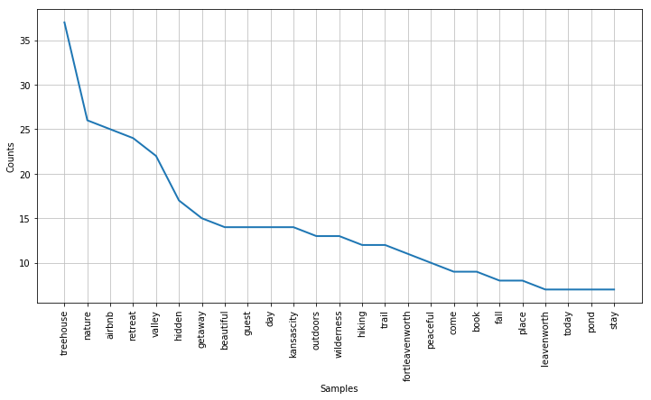

```python
post_tokens = []
tokens = str(texts)
tokens = tokens.lower()
tokens = re.sub("[^a-zA-Z0-9]", " ", tokens)
tokens2 = word_tokenize(tokens)
for token in tokens2:
    if token != "u":
        post_tokens.append(token)
fdist = nltk.FreqDist(post_tokens)
plt.figure(figsize=(12,6))
fdist.plot(25)
```

### The Graph above displays the most common words used in posts by the facebook page itself. As you can see from the most common used words, the page looks to highlight the treehouses, nature, airbnb (where they are rented out), and the beauty of the business. Other topics talk about the wilderness, hiking, ponds. We will use this data later to see if their posts are accurately tailored to what their customers are looking for.

# Fan Page Metrics

### Using the results of the python script, we are going to analyze how popular the page is.

```python
Total_Likes = 0
Total_PostsWLikes = 0
Total_Posts = 0
Comments = 0
Total_Comments = 0
Share = 0
Total_Shares = 0
Followers = 653

first = True;

r = csv.reader(open('hiddenvalleywilderness_facebook_statuses.csv', 'rb'))
for row in r:
    if (first == False):
        Total_Posts += 1
        if (int(row[6]) > 0):
            Total_PostsWLikes += 1
            Total_Likes += int(row[6])

        if (int(row[7]) > 0):
            Comments += 1
            Total_Comments += int(row[7])


        if (int(row[8]> 0)):
            Share += 1
            Total_Shares += int(row[8])


    first = False



p1 = float(float(Total_PostsWLikes)/float(Total_Posts))
p2 = Total_Likes/Total_Posts
p3 = (float((float(p2)/float(Followers)))*1000)
c1 = float(float(Comments) / float(Total_Posts))
c2 = float(float(Total_Comments) / float(Total_Posts))
c3 = (float((float(c2)/Followers))*1000)
v1 = float(float(Share) / float(Total_Posts))
v2 = float(float(Total_Shares) / float(Total_Posts))
v3 = (float((float(v2)/Followers))*1000)
```

```python
print("p1 = " + str(p1))
print("p2 = " + str(p2))
print("p3 = " + str(p3))
print("c1 = " + str(c1))
print("c2 = " + str(c2))
print("c3 = " + str(c3))
print("v1 = " + str(v1))
print("v2 = " + str(v2))
print("v3 = " + str(v3))
```

```
p1 = 0.940298507463
p2 = 12
p3 = 18.3767228178
c1 = 0.268656716418
c2 = 1.05970149254
c3 = 1.62282004983
v1 = 1.0
v2 = 2.31343283582
v3 = 3.54277616512
```

### 9. All the posts have at least one share.

### 10. The pages posts average 2.31 shares per post

### 11. They do have posts that gain popularity

# Data

### We also need to analyze the comments on the posts. Once we have the comments we can perform sentiment analysis, content analysis, descriptive analytics, and topic modeling.

```python
##the access_token is only valid for about an hour so everytime you want data to be updated, paste a new access code here.
access_token = 'EAACEdEose0cBACAZBBAAWUajvaFVkEHfnhiKVX0ZAh79bunAYw4RxQ3KLjE…'
page_id = 'hiddenvalleywilderness'
graph = facebook.GraphAPI(access_token, version='2.7')
```

```python
CommentData=[]

fields = "created_time,message,type,name,id," + \
            "shares,reactions.limit(0).summary(true)," +\
                "comments{id,message,created_time,comments,from,like_count}"

data = graph.get_object(id='hiddenvalleywilderness/feed/', fields=fields)

# you can use since parameter to limit the amount of data
#data = graph.get_object(id='383Indians/feed/', fields=fields, since='2018-03-01')

# retrieve data
while(True):
    try:
        for i in data['data']:
            CommentData.append(i)
        # Attempt to make a request to the next page of data, if it exists.
        data=requests.get(data['paging']['next']).json()
    except KeyError:
        # When there are no more pages (['paging']['next']), break from the
        # loop and end the script.
        break
len(CommentData)
```

```
67
```

```python
def getCommentMessages(d):
    comm_list=[]  # Empty list to hold comments messages.
    if isinstance(d, dict):  # Check to see that a dictionary was passed into the function
        if isinstance(d['data'][0], dict):  # Are there actual comments data nodes?
            for i in d['data']:   # Iterate through the nodes under the ['comments']['data]
                if i['message']:  # Check that value exists
                    if isinstance(i, dict):
                        #print i['message'], i['like_count']
                        comm_list.append([i['message'],i['like_count']])  # Append message to comments list
            return comm_list  # Return the comments list
```

```python
df2.comments.apply(lambda x: getCommentMessages(x))
```

```
0                                                  None
1     [[Beautiful!, 1], [This truly is a magical lit...
2                                                  None
3     [[Be careful !!!!, 1], [Why is it named after ...
4                                                  None
5     [[Jack Wardrop amazing isnt it?, 1], [Come vis...
6                                     [[Peaceful!!, 1]]
7                                                  None
8                                                  None
9                                                  None
10                                                 None
11                                                 None
12    [[Tara McGee Knutsen, 1], [Beautiful!!, 1], [S...
13                                                 None
14                                                 None
```

[output cut: 47 more lines]

```python
df2['new_comments']= df2.comments.apply(lambda x: getCommentMessages(x))
df2_comments = df2.dropna(subset=['new_comments'])
df2_comments.head()
```

|  | comments | created_time | id | message | name | reactions | shares | type | new_comments |
| --- | --- | --- | --- | --- | --- | --- | --- | --- | --- |
| 1 | {u'paging': {u'cursors': {u'after': u'WTI5dGJX... | 2018-04-25T22:49:00+0000 | 1252406928126387_1903609896339417 | Recent Guest Reviews:\n\n"This place is charmi... | Hidden Valley Wilderness Retreat | {u'data': [], u'summary': {u'total_count': 51,... | {u'count': 14} | photo | [[Beautiful!, 1], [This truly is a magical lit... |
| 3 | {u'paging': {u'cursors': {u'after': u'WTI5dGJX... | 2018-02-15T15:25:34+0000 | 1252406928126387_1828441337189607 | Following a few months of recovery from an unf... | NaN | {u'data': [], u'summary': {u'total_count': 37,... | {u'count': 2} | photo | [[Be careful !!!!, 1], [Why is it named after ... |
| 5 | {u'paging': {u'cursors': {u'after': u'WTI5dGJX... | 2017-11-12T03:21:53+0000 | 1252406928126387_1729733897060352 | Hidden Valley Wilderness Retreat is located on... | Photos from Hidden Valley Wilderness Retreat's... | {u'data': [], u'summary': {u'total_count': 47,... | {u'count': 44} | photo | [[Jack Wardrop amazing isnt it?, 1], [Come vis... |
| 6 | {u'paging': {u'cursors': {u'after': u'WTI5dGJX... | 2017-11-06T19:43:19+0000 | 1252406928126387_1724708780896197 | Fall is giving beautiful colors here at Hidden... | Photos from Hidden Valley Wilderness Retreat's... | {u'data': [], u'summary': {u'total_count': 19,... | {u'count': 3} | photo | [[Peaceful!!, 1]] |
| 12 | {u'paging': {u'cursors': {u'after': u'WTI5dGJX... | 2017-09-12T13:06:23+0000 | 1252406928126387_1673902752643467 | NaN | 's cover photo | {u'data': [], u'summary': {u'total_count': 24,... | NaN | photo | [[Tara McGee Knutsen, 1], [Beautiful!!, 1], [S... |

```python
df2_list = df2_comments['new_comments'].tolist()
final_comments = []
for a in df2_list:
    for b in a:
        #print b[0], b[1]
        final_comments.append(b[0])

df_fin_comments = pd.DataFrame(final_comments)
df_fin_comments = df_fin_comments.rename(columns={0: 'comment'})
df_fin_comments.head()
```

|  | comment |
| --- | --- |
| 0 | Beautiful! |
| 1 | This truly is a magical little get away!! 💗💗💗 |
| 2 | I want to come back and stay a night and spend... |
| 3 | Be careful !!!! |
| 4 | Why is it named after Graham? 😀 |

```python
# Remove useless numbers and alphanumerical words
documents2 = [re.sub("[^a-zA-Z]+", " ", text) for text in final_comments]

# tokenize
texts2 = [[word for word in text.lower().split() ] for text in documents2]

# stemming words: having --> have; friends --> friend
lmtzr2 = WordNetLemmatizer()
texts2 = [[lmtzr.lemmatize(word) for word in text ] for text in texts2]

#porter_stemmer = PorterStemmer()

#texts = [[porter_stemmer.stem(word) for word in text ] for text in texts]

# remove common words
stoplist = stopwords.words('english')
texts2 = [[word for word in text if word not in stoplist] for text in texts2]

#remove short words
texts2 = [[ word for word in tokens if len(word) >= 3 ] for tokens in texts2]
extra_stopwords = ['n','u','nthe','com','www','even','could','two','may', 'llc','best','http']
extra_stoplist = extra_stopwords
texts2 = [[word for word in text if word not in extra_stoplist] for text in texts2]
```

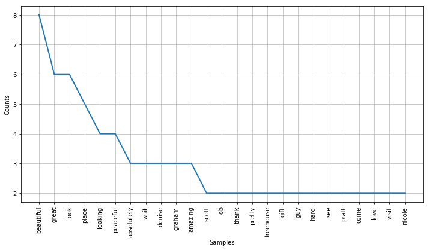

```python
tokens4 = []
tokens3 = str(texts2)
tokens3 = tokens3.lower()
tokens3 = re.sub("[^a-zA-Z0-9]", " ", tokens3)
tokens3 = word_tokenize(tokens3)
for token in tokens3:
    if token != "u":
        tokens4.append(token)
fdist = nltk.FreqDist(tokens4)
plt.figure(figsize=(12,6))
fdist.plot(25)
```

### Above you can see a graph of the most common words that are commented on their facebook posts.

# We also want to collect the data from the reviews sections on the page not just comments on their posts. The reviews is where we can analyze what people that have actually stayed at the retreat think of the retreat

```python
ReviewData=[]

fields = "review_text,rating" + \
                "reviews{review_text,rating}"

data = graph.get_object(id='hiddenvalleywilderness/ratings/', fields=fields)


# retrieve data
while(True):
    try:
        for i in data['data']:
            ReviewData.append(i)
        # Attempt to make a request to the next page of data, if it exists.
        data=requests.get(data['paging']['next']).json()
    except KeyError:
        # When there are no more pages (['paging']['next']), break from the
        # loop and end the script.
        break
```

```python
len(ReviewData)
```

```
8
```

```python
def getReviewMessages(d):
    review_list=[]  # Empty list to hold comments messages.
    if isinstance(d, dict):  # Check to see that a dictionary was passed into the function
        if isinstance(d['data'][0], dict):  # Are there actual comments data nodes?
            for i in d['data']:   # Iterate through the nodes under the ['comments']['data]
                if i['review_text']:  # Check that value exists
                    if isinstance(i, dict):
                        #print i['message'], i['like_count']
                        review_list.append([i['review_text'],i['rating']])  # Append message to comments list

            return review_list  # Return the comments list
```

```python
df_3 = pd.DataFrame.from_dict(ReviewData)
df_3.head()
```

|  | review_text |
| --- | --- |
| 0 | I highly recommend a night or a weekend spent ... |
| 1 | This place is perfection!! We will be back man... |
| 2 | This place is incredible! It was the perfect g... |
| 3 | Hidden Valley Wilderness Retreat is such an am... |
| 4 | Where do we start? The moment we pulled up to ... |

```python
df_3_list = df_3['review_text'].tolist()

df_3_list[:11]
```

```
[u"I highly recommend a night or a weekend spent in peace at Hidden Valley!!! Stan and Denise make you feel like you just got home. It's so quiet and serene we forgot we were only 10 miles from home. The treehouse is AMAZING!!! \nThis could be Leavenworth County's best kept secret.\nWE WILL BE BACK!…
 u'This place is perfection!! We will be back many times, I am sure of it! An easy drive from the city and you feel like you are a thousand miles away! A comfortable place that is easy to settle into and the grounds are exquisite w sweet touches like a fountain, fire pit, hammocks available, and so …
 u'This place is incredible! It was the perfect getaway for my wife and I. The place is gorgeous and has an amazing view of nature. The hosts are thoughtful and provide wonderful details in their service that make your stay special. We had a blast feeding the ducks and sitting on the back porch area…
 u'Hidden Valley Wilderness Retreat is such an amazing and beautiful place to visit! The grounds are gorgeous, the house is comfy, homey, and beautiful! No detail went unnoticed. The hosts are super sweet and you can tell they genuinely care about their guests and their retreat. My husband and I lov…
 u"Where do we start? The moment we pulled up to the gate we instantly were giddy with excitement. This beautiful retreat nestled in the woods is what everyone needs in their life. The main house is so roomy and comfortable and inviting. The king sized bed was perfect and we slept better than we hav…
 u"What a treat!  So wonderful to have this right outside of Leavenworth!! The treehouse is just darling and so comfy.  And the main house is so homey and woodsy. We loved everything... the hiking trails, the koy pond, the firepit and smores, the beautiful treehouse, even the plush towels in the bat…
 u"ABSOLUTELY WONDERFUL! You would be hard pressed to find better hosts!! Stan and Denise are so accommodating. We are leaving feeling refreshed and relaxed.... and sad to leave our new friends. We were honored to be the first treehouse guests and thoroughly enjoyed our time! We can't wait to come b…
 u"After a hard week, Gary and I escaped to visit our friends, Denise and Stan Woods, at their new B&B just north of Leavenworth. To say we were pampered, was an understatement. It was an oasis with rustic charm with miles of wooded paths to unwind. If you are a couple needing  a 'do over', consider…
```

```python
Final_Reviews = []
for a in df_3_list:
    Final_Reviews.append(a)


df_fin_reviews = pd.DataFrame(Final_Reviews)
df_fin_reviews = df_fin_reviews.rename(columns={0: 'Review'})
df_fin_reviews.head()
```

|  | Review |
| --- | --- |
| 0 | I highly recommend a night or a weekend spent ... |
| 1 | This place is perfection!! We will be back man... |
| 2 | This place is incredible! It was the perfect g... |
| 3 | Hidden Valley Wilderness Retreat is such an am... |
| 4 | Where do we start? The moment we pulled up to ... |

```python
Final_Reviews
```

```
[u"I highly recommend a night or a weekend spent in peace at Hidden Valley!!! Stan and Denise make you feel like you just got home. It's so quiet and serene we forgot we were only 10 miles from home. The treehouse is AMAZING!!! \nThis could be Leavenworth County's best kept secret.\nWE WILL BE BACK!…
 u'This place is perfection!! We will be back many times, I am sure of it! An easy drive from the city and you feel like you are a thousand miles away! A comfortable place that is easy to settle into and the grounds are exquisite w sweet touches like a fountain, fire pit, hammocks available, and so …
 u'This place is incredible! It was the perfect getaway for my wife and I. The place is gorgeous and has an amazing view of nature. The hosts are thoughtful and provide wonderful details in their service that make your stay special. We had a blast feeding the ducks and sitting on the back porch area…
 u'Hidden Valley Wilderness Retreat is such an amazing and beautiful place to visit! The grounds are gorgeous, the house is comfy, homey, and beautiful! No detail went unnoticed. The hosts are super sweet and you can tell they genuinely care about their guests and their retreat. My husband and I lov…
 u"Where do we start? The moment we pulled up to the gate we instantly were giddy with excitement. This beautiful retreat nestled in the woods is what everyone needs in their life. The main house is so roomy and comfortable and inviting. The king sized bed was perfect and we slept better than we hav…
 u"What a treat!  So wonderful to have this right outside of Leavenworth!! The treehouse is just darling and so comfy.  And the main house is so homey and woodsy. We loved everything... the hiking trails, the koy pond, the firepit and smores, the beautiful treehouse, even the plush towels in the bat…
 u"ABSOLUTELY WONDERFUL! You would be hard pressed to find better hosts!! Stan and Denise are so accommodating. We are leaving feeling refreshed and relaxed.... and sad to leave our new friends. We were honored to be the first treehouse guests and thoroughly enjoyed our time! We can't wait to come b…
 u"After a hard week, Gary and I escaped to visit our friends, Denise and Stan Woods, at their new B&B just north of Leavenworth. To say we were pampered, was an understatement. It was an oasis with rustic charm with miles of wooded paths to unwind. If you are a couple needing  a 'do over', consider…
```

# Data Cleaning & Text Preprocessing for Reviews

```python
# Remove useless numbers and alphanumerical words
documents3 = [re.sub("[^a-zA-Z]+", " ", text) for text in Final_Reviews]

# tokenize
texts3 = [[word for word in text.lower().split() ] for text in documents3]

# stemming words: having --> have; friends --> friend
lmtzr3 = WordNetLemmatizer()
texts3= [[lmtzr.lemmatize(word) for word in text ] for text in texts3]

#porter_stemmer = PorterStemmer()

#texts = [[porter_stemmer.stem(word) for word in text ] for text in texts]

# remove common words
stoplist = stopwords.words('english')
texts3 =[[word for word in text if word not in stoplist] for text in texts3]

#remove short words
texts3 = [[ word for word in tokens if len(word) >= 3 ] for tokens in texts3]
extra_stopwords = ['n','u','nthe','com','www','even','could','two','may', 'llc','best','http']
extra_stoplist = extra_stopwords
texts3 = [[word for word in text if word not in extra_stoplist] for text in texts3]
```

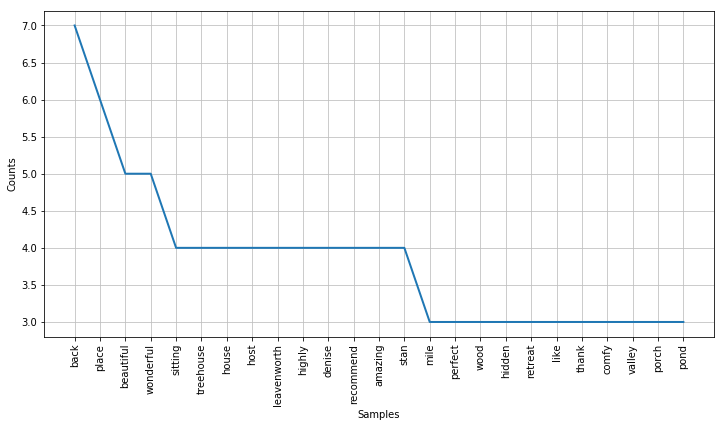

```python
tokens_final_Reviews = []
tokensReview = str(texts3)
tokensReview = tokensReview.lower()
tokensReview = re.sub("[^a-zA-Z0-9]", " ", tokensReview)
tokensReview = word_tokenize(tokensReview)
for token in tokensReview:
    if token != "u":
        tokens_final_Reviews.append(token)
fdist = nltk.FreqDist(tokens_final_Reviews)
plt.figure(figsize=(12,6))
fdist.plot(25)
```

# Data Collection via webscraping Airbnb

## Additional Reviews are scraped off the page for the tree house on airbnb

import requests from lxml import html import csv import pandas as pd r = requests.get('https://www.airbnb.com/users/show/61989089') data = html.fromstring(r.text) AirbnbReviews = data.xpath("//p/text()")

## Once the data is scraped it is saved to csv file to be opened later

```python
AirbnbReviewsDG = pd.DataFrame(AirbnbReviews)
AirbnbReviewsDG.head()
```

|  | 0 |
| --- | --- |
| 0 | I'm a retired IT guy who is an avid runner, bi... |
| 1 | It was a special place. Beautiful trails, bird... |
| 2 | We have stayed at many (Hidden by Airbnb) and ... |
| 3 | The retreat is definitely worth a visit! So mu... |
| 4 | We were looking for an easy weekend get away t... |

csvfile = "AirbnbReviews.csv" #Assuming res is a flat list with open(csvfile, "w") as output: writer = csv.writer(output, lineterminator='\n') for val in AirbnbReviews: try: writer.writerow([val]) except ValueError: print("")

## Combine the two sources of Reviews into one data set.

```python
AirbnbReviews = csv.reader(open('AirbnbReviews.csv', 'rb'))

combinedReviews = []

for row in AirbnbReviews:
    combinedReviews.append(row)

combinedReviews = [x for y in combinedReviews for x in y]
for row in Final_Reviews:
    combinedReviews.append(row)
```

```python
#
```

```python
# Remove useless numbers and alphanumerical words
documents = [re.sub("[^a-zA-Z]+", " ", str(text)) for text in combinedReviews]

# tokenize
texts = [[word for word in text.lower().split() ] for text in documents]

# stemming words: having --> have; friends --> friend
lmtzr = WordNetLemmatizer()
texts = [[lmtzr.lemmatize(word) for word in text ] for text in texts]

#porter_stemmer = PorterStemmer()
#texts = [[porter_stemmer.stem(word) for word in text ] for text in texts]

# remove common words
stoplist = stopwords.words('english')
texts = [[word for word in text if word not in stoplist] for text in texts]

#remove short words
texts = [[ word for word in tokens if len(word) >= 3 ] for tokens in texts]

extra_stopwords = ['n','u','place','denise','stan','even','host','stay','may', 'llc','best','http']
extra_stoplist = extra_stopwords
Combinedtexts = [[word for word in text if word not in extra_stoplist] for text in texts]
```

# Word Cloud analysis

## We are going to word Cloud analysis based on the data collected from the Facebook posts, comments, and combined Reviews.

```python
from os import path
from PIL import Image
import numpy as np
import matplotlib.pyplot as plt
from wordcloud import WordCloud, STOPWORDS, ImageColorGenerator
```

## Facebook Posts

```
<wordcloud.wordcloud.WordCloud at 0x20d48128>
```

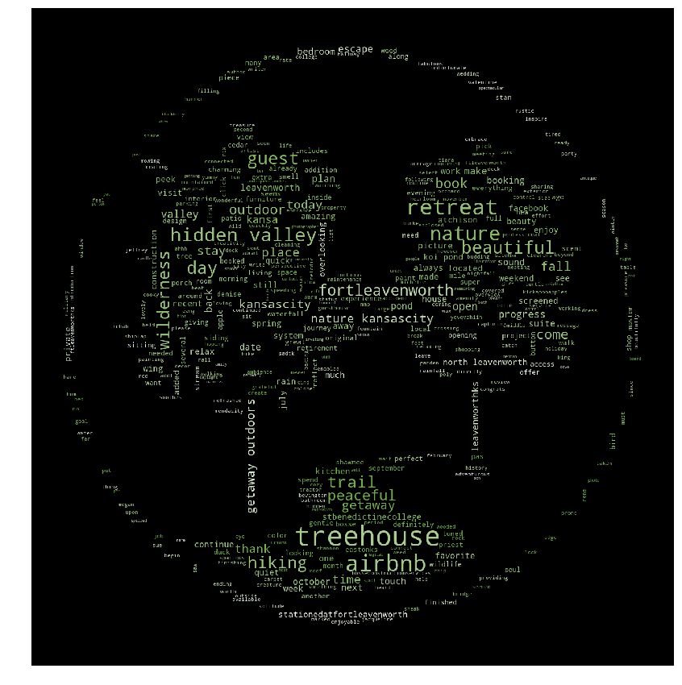

```python
Mask = np.array(Image.open("hvlogopic.jpg"))
stopwords = set(STOPWORDS)
stopwords.add("said")
stopwords.add("'")
stopwords.add("going")
stopwords.add("america")
stopwords.add("american")
stopwords.add("year")
stopwords.add("americans")
# Generate a word cloud image

wc = WordCloud(background_color="black", max_words=450, mask=Mask,
               stopwords=stopwords, max_font_size=60, random_state=42).generate(str(tokens))


image_colors = ImageColorGenerator(Mask)




# recolor wordcloud and show
# we could also give color_func=image_colors directly in the constructor
plt.figure(figsize=(15,15))
plt.imshow(wc.recolor(color_func=image_colors))
plt.axis("off")

plt.figure()
plt.imshow(Mask, cmap=plt.cm.gray)
plt.axis("off")

wc.to_file("hiddenvalleyWordCloud.png")
```

## From the cloud created above, using the companies emblem. The primary attributes that are highlighted by Hidden Valley Wilderness retreat are biggest in the Word Cloud. Such as the name, location, amenities, and selling points of the retreat. (nature, beautiful, treahouse, trail, peaceful, getaway)

```
(-0.5, 1420.5, 1454.5, -0.5)
```

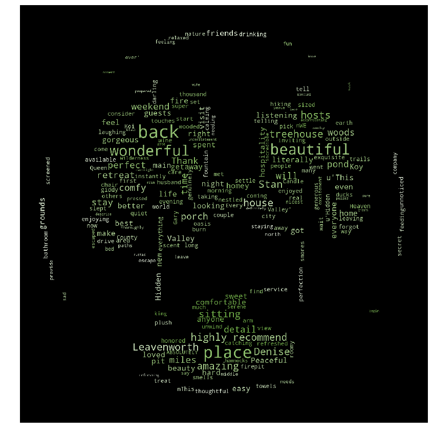

```python
Mask = np.array(Image.open("hvlogopic.jpg"))
stopwords = set(STOPWORDS)
stopwords.add("said")
stopwords.add("'")
stopwords.add("going")
stopwords.add("america")
stopwords.add("american")
stopwords.add("nan")
stopwords.add("americans")
# Generate a word cloud image

wc = WordCloud(background_color="black", max_words=450, mask=Mask,
               stopwords=stopwords, max_font_size=60, random_state=42).generate(str(df_3_list))


image_colors = ImageColorGenerator(Mask)




# recolor wordcloud and show
# we could also give color_func=image_colors directly in the constructor
plt.figure(figsize=(15,15))
plt.imshow(wc.recolor(color_func=image_colors))
plt.axis("off")

plt.figure()
plt.imshow(Mask, cmap=plt.cm.gray)
plt.axis("off")


wc.to_file("hiddenvalleyWordCloud2.png")
plt.axis("off")
```

# Comments Word Cloud

```
<wordcloud.wordcloud.WordCloud at 0x18df8160>
```

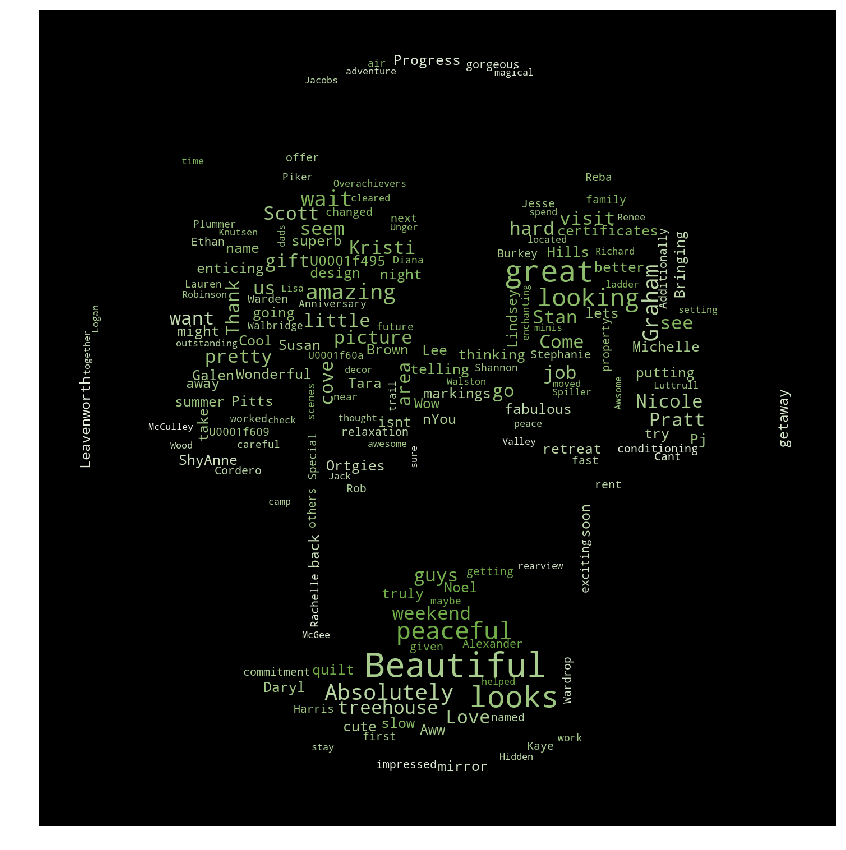

```python
Mask = np.array(Image.open("hvlogopic.jpg"))
comment_array = re.sub("[^a-zA-Z0-9]", " ", str(df2_list))
stopwords = set(STOPWORDS)
stopwords.add("Denise")
stopwords.add("'")
stopwords.add("place")
stopwords.add("u'")
stopwords.add("U0001f497")
stopwords.add("U0001f60d")
stopwords.add("U0001f600")
# Generate a word cloud image

wc = WordCloud(background_color="black", max_words=500, mask=Mask,
               stopwords=stopwords, max_font_size=60, random_state=42).generate(str(comment_array))


image_colors = ImageColorGenerator(Mask)




# recolor wordcloud and show
# we could also give color_func=image_colors directly in the constructor
plt.figure(figsize=(15,15))
plt.imshow(wc.recolor(color_func=image_colors))
plt.axis("off")

plt.figure()
plt.imshow(Mask, cmap=plt.cm.gray)
plt.axis("off")

wc.to_file("hiddenvalleyWordCloud3.png")
##plt.savefig("hiddenvalleyWordCloud3.png")
```

## The wordcloud associated with the comments show us peoples reaction to the information posted to Facebook. Based on the word cloud we can see that people's most common reactions are of admiration (beautiful, great, amazing, love, etc)

# WordCloud based on Combined Reviews

## This is the most beneficial Word Cloud since it is made of the words that the customers of Hidden Valley Wilderness retreat leave in their reviews. This image is important becuase it will be used as marketing material to highlight all the things that people love about the retreat.

```
(-0.5, 1420.5, 1454.5, -0.5)
```

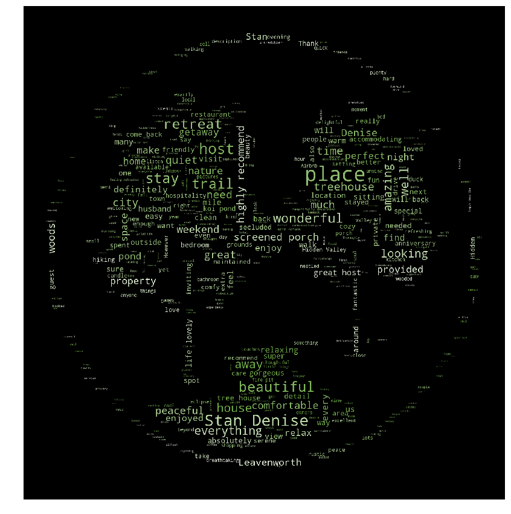

```python
text = open('Reviews.txt').read()

Mask = np.array(Image.open("hvlogopic.jpg"))
stopwords = set(STOPWORDS)
stopwords.add("said")
stopwords.add("'")
stopwords.add("going")
stopwords.add("america")
stopwords.add("american")
stopwords.add("nan")
stopwords.add("americans")
# Generate a word cloud image

wc = WordCloud(background_color="black", max_words=450, mask=Mask,
               stopwords=stopwords, max_font_size=60, random_state=42).generate(str(combinedReviews))


image_colors = ImageColorGenerator(Mask)




# recolor wordcloud and show
# we could also give color_func=image_colors directly in the constructor
plt.figure(figsize=(15,15))
plt.imshow(wc.recolor(color_func=image_colors))
plt.axis("off")

plt.figure()
plt.imshow(Mask, cmap=plt.cm.gray)
plt.axis("off")


#wc.to_file("hiddenvalleyWordCloud_combinedReviews.png")
plt.axis("off")
```

```python
# Remove useless numbers and alphanumerical words
documents = [re.sub("[^a-zA-Z]+", " ", str(text)) for text in combinedReviews]

# tokenize
texts = [[word for word in text.lower().split() ] for text in documents]

# stemming words: having --> have; friends --> friend
lmtzr = WordNetLemmatizer()
texts = [[lmtzr.lemmatize(word) for word in text ] for text in texts]

#porter_stemmer = PorterStemmer()
#texts = [[porter_stemmer.stem(word) for word in text ] for text in texts]

# remove common words
stoplist = stopwords.words('english')
texts = [[word for word in text if word not in stoplist] for text in texts]

#remove short words
texts = [[ word for word in tokens if len(word) >= 3 ] for tokens in texts]

extra_stopwords = ['n','u','place','denise','stan','even','host','stay','may', 'llc','best','http']
extra_stoplist = extra_stopwords
Combinedtexts = [[word for word in text if word not in extra_stoplist] for text in texts]
```

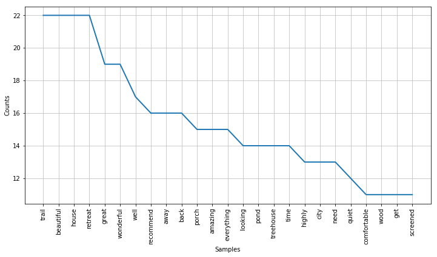

```python
finalTokens = []
tokens = str(Combinedtexts)
tokens = tokens.lower()
tokens = re.sub("[^a-zA-Z0-9]", " ", tokens)
tokens = word_tokenize(tokens)
for token in tokens:
    if token != "u":
        finalTokens.append(token)
fdist = nltk.FreqDist(finalTokens)
plt.figure(figsize=(12,6))
fdist.plot(25)
```

# Sentiment Analysis

## Evaluate whether the reviews are positive or negative. We know that Hidden Valley Wilderness Retreat has a perfect 5/5 rating on Airbnb and Facebook. However we want to evaluate whether these ratings are accurate. Considering that Airbnb has a mutual rating system, it is possible for ratings to be skewed since people may rate something positive in the hopes that the favor will be returned

```python
from pattern.en import sentiment
import csv
import pandas as pd

import re

import nltk
from nltk.corpus import stopwords
```

```python
positive_review = []
negative_review = []
neutral_review = []
Review_Scores = []
for row in combinedReviews:
    score = sentiment(row)
    if score[0] > 0:
        positive_review.append(row)
    elif score[0] == 0:
        neutral_review.append(row)
    else:
        negative_review.append(row)
    Review_Scores.append({score, row})
```

```python
print len(positive_review)
print len(negative_review)
print len(neutral_review)
```

```
57
1
0
```

## Based on the scores the program says that all of the reviews are actually positive except for one.

```python
negative_review
```

```
[u"After a hard week, Gary and I escaped to visit our friends, Denise and Stan Woods, at their new B&B just north of Leavenworth. To say we were pampered, was an understatement. It was an oasis with rustic charm with miles of wooded paths to unwind. If you are a couple needing  a 'do over', consider…
```

## However, when we look at the review, we can determine that the algorith detected a false negative. Therefore we can conclude the ratings on Facebook and Airbnb are actually all positive.

# Topic Modeling for Reviews

```python
import gensim
print gensim.__version__
from gensim.corpora import Dictionary
from gensim.models import ldamodel
import numpy
%matplotlib inline
from gensim.models.coherencemodel import CoherenceModel
from gensim.models.wrappers import LdaVowpalWabbit, LdaMallet


import warnings
warnings.filterwarnings(action='ignore', category=UserWarning)  # To ignore all warnings that arise here to enhance clarity
import csv
import pandas as pd

# import packages for text processing
import nltk
from nltk.corpus import stopwords
from nltk.stem.wordnet import WordNetLemmatizer
from nltk.stem.porter import PorterStemmer
import re

import gensim
from gensim.corpora import Dictionary
from gensim.models import ldamodel
from gensim import corpora, models, similarities

from gensim.models.coherencemodel import CoherenceModel
from gensim.models.wrappers import LdaVowpalWabbit, LdaMallet

import numpy
import matplotlib.pyplot as plt
%matplotlib inline

import warnings
warnings.filterwarnings('ignore')  # To ignore all warnings that arise here to enhance clarity
```

```
3.4.0
```

## Create a dictionary representation of the documents. dictionary = Dictionary(Combinedtexts) dictionary.save('review.dict') # store the dictionary, for future reference ## Remove rare and common tokens. dictionary.filter_extremes(no_below=2, no_above=0.4) # convert words to vetors or integers corpus = [dictionary.doc2bow(text) for text in Combinedtexts] corpora.MmCorpus.serialize('CorpusReviews.mm', corpus) # store to disk, for later use # store to disk, for later use

```python
print('Number of unique tokens: %d' % len(dictionary))
print('Number of documents: %d' % len(corpus))
```

```
Number of unique tokens: 327
Number of documents: 58
```

## Building the model

numpy.random.seed(1) k_range = range(10,100) #this process could take very long ... scores = [] for k in k_range: goodLdaModel = ldamodel.LdaModel(corpus=corpus, id2word=dictionary, num_topics=k, passes=50) goodcm = CoherenceModel(model=goodLdaModel, corpus=corpus, dictionary=dictionary, coherence='u_mass') print k, goodcm.get_coherence() scores.append(goodcm.get_coherence())

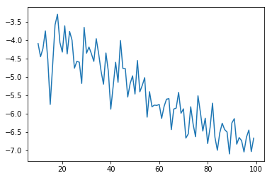

```python
plt.figure()
plt.plot(k_range, scores)
```

# numpy.random.seed(1) # setting random seed to get the same results each time. model = ldamodel.LdaModel(corpus, id2word=dictionary, num_topics=15, passes=20, eval_every = 1) numpy.random.seed(1) # setting random seed to get the same results each time. model = ldamodel.LdaModel(corpus, id2word=dictionary, num_topics=15, passes=30, eval_every = 1)model.save('lda_Review.model')

```python
for i in range(0,15):
    topics = model.show_topic(i, 10)
    print ', '.join([str(word[0]) for word in topics])
```

[output not shown]

```python
lda_corpus = model[corpus]

results = []
for i in lda_corpus:
    results.append(i)
```

```python
toptopic = [max(collection, key=lambda x: x[1])[0] for collection in results]
toptopic = pd.DataFrame(toptopic)
documents = pd.DataFrame(documents)
documents = documents.rename(columns = {0: 'documents'})
summary = documents.join(toptopic)
summary.head()
```

[output not shown]

```python
toptopic = pd.DataFrame(toptopic)
documents = pd.DataFrame(documents)
documents = documents.rename(columns = {0: 'documents'})
summary = documents.join(toptopic)
summary
```

[output not shown]

```python
summary.groupby(0).count()
```

| 0 | documents |
| --- | --- |
| 0.0 | 3 |
| 1.0 | 2 |
| 2.0 | 6 |
| 3.0 | 6 |
| 4.0 | 1 |
| 5.0 | 1 |
| 6.0 | 4 |
| 7.0 | 5 |
| 8.0 | 5 |
| 9.0 | 6 |
| 11.0 | 2 |
| 12.0 | 5 |
| 13.0 | 7 |
| 14.0 | 5 |

```python
import pyLDAvis.gensim
```

```python
pyLDAvis.enable_notebook()
pyLDAvis.gensim.prepare(model, corpus, dictionary)
```

[interactive chart not shown]